# Meta-analysis: Immune-checkpoint blockade (ICB) data

2022-08-16

## Load data

To download and extract TSV version of ICB data from Zenodo (https://zenodo.org/record/7058399/files/), follow the script named download_tsv_data R file at “~/Code/Download_Data”.

We read RNA-seq expression, clinicopathological characteristics, and gene meta data for the following selected ICB studies to include in meta-analysis.

1. Braun (PMID 32472114)
2. Gide (PMID 30753825)
3. Hugo (PMID 26997480)
4. Kim (PMID 30013197)
5. Miao1 (PMID 29301960)
6. Nathanson (PMID 27956380)
7. Riaz (PMID 29301960)
8. Snyder (PMID 28552987)
9. Van Allen (PMID 26359337)
10. VanDenEnde (PMID 33504550)

As an example, we share the codes to get read the RNA-seq expression, clinicopathological characteristics, and gene meta data usign ICB Braun data. The Braun study includes 319 patients with clinical data and 40,994 genes. While only 181 patients have both clinical data and RNA-seq expression data.

Note that the expression data is $log2(\text{TPM} + 0.001)$, where TPM represents transcripts per million.

### Braun study

```r
# clinicopathological characteristics
dat_sample_braun = read.table('C:/IOProject/Data/ICB_Braun/ICB_Braun_metadata.tsv', sep="\t") %>% as.data.frame()
dim(dat_sample_braun)
```

```
## [1] 319 145
```

```r
# gene meta data
dat_gene_braun = read.table('C:/IOProject/Data/ICB_Braun/ICB_Braun_expr_genes.tsv', sep="\t") %>% as.data.frame()
dim(dat_gene_braun)
```

```
## [1] 40994    17
```

```r
# RNA-seq expression data (i.e., log2(TPM + 0.001))
dat_exp_braun = read.table('C:/IOProject/Data/ICB_Braun/ICB_Braun_expr.tsv', sep="\t") %>% as.data.frame()
dim(dat_exp_braun)
```

```
## [1] 40994   181
```

```r
# Get the subset of data with both clinical and expression data.

dat_sample_braun = dat_sample_braun[rownames(dat_sample_braun) %in% colnames(dat_exp_braun), ]

dim(dat_sample_braun)
```

```
## [1] 181 145
```

```r
dat_sample_braun <- dat_sample_braun[order(rownames(dat_sample_braun)), ]
dat_exp_braun <- dat_exp_braun[, order(colnames(dat_exp_braun))]
```

## Logistic regression analysis

For each study, we assess the association between genes and response variable (R vs NR) by fitting the logistic regression model. For a given gene, we fit the model under each study to identify the log(OR) and its standard error (SE). We consider a gene (e.g., ENSG00000065491.8 or TBC1D22B) that is in common across selected ICB studies.

```r
logit_res <- lapply(1:length(dat_exp), function(k){

  print(k)
  sub_dat_exp <- dat_exp[[k]]
  sub_pdata <- pdata[[k]]

  df <- data.frame(x = as.numeric(sub_dat_exp[rownames(sub_dat_exp) == "ENSG00000065491.8",]),
                   y = sub_pdata$response)

  df <- df[!is.na(df$y),]
  df$y <- factor(df$y)
  df$y <- ifelse(df$y == "R", 0, 1)

  fit <- glm( y ~ x,
            data = df,
            family = "binomial")

fit_summary <- summary(fit)

 data.frame(gene_id = "ENSG00000065491.8",
           "logOR" = fit_summary$coefficients["x", "Estimate"],
           "SE" = fit_summary$coefficients["x", "Std. Error"],
           "pvals" = fit_summary$coefficients["x", "Pr(>|z|)"])
 })
```

```
## [1] 1
## [1] 2
## [1] 3
## [1] 4
## [1] 5
## [1] 6
## [1] 7
## [1] 8
## [1] 9
## [1] 10
```

```r
logit_res <- do.call(rbind, logit_res)
rownames(logit_res) <- names(dat_exp)
```

## Meta-analysis

Meta-analyses can be performed to integrate independent studies to identify more reliable findings by increasing statistical power and reducing false positives. The strengths and limitations of meta-analyses are evaluated particularly with respect to their ability to assess variation across studies or heterogeneity. Several meta-analysis methods have been proposed such as combining p-values, combining effect estimates, and rankings.

Approaches that combine effects including fixed- and random-effects (FE & RE) models are widely used to achieve a broad inferential basis for evaluations of effects. Under the FE model, we assume that there is one true effect that underlies all the studies in the analysis, and that all differences in observed effects are due to sampling error. In contrast, the RE model incorporates the variability of the effects across studies in addition to the within-study variability using a two-stage hierarchical process.

Assessing heterogeneity is a critical issue in meta-analysis because different models may lead to different estimates of overall effect and different standard errors.Several approaches have been suggested over the years for how best to assess homogeneity across studies, and the corresponding research is ongoing. DerSimonian and Laird (DL) (or chi2) is widely used to assess the heterogeneity.

### Part I: response (R vs. NR)

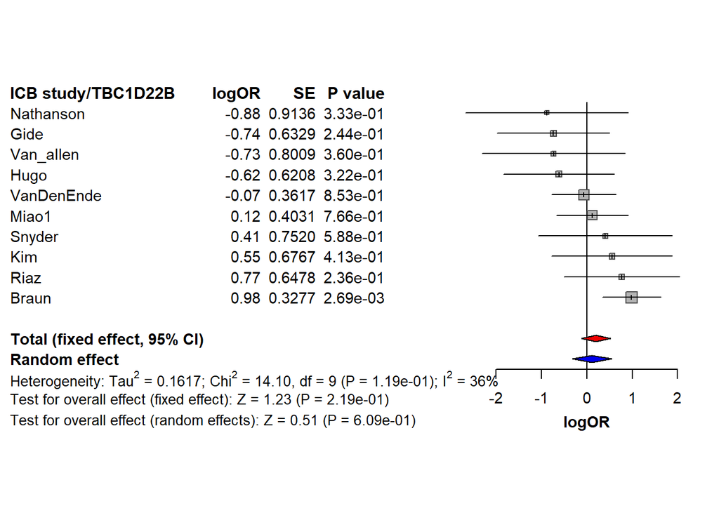

```r
dat_meta <- logit_res

x <-  dat_meta$logOR
y <- dat_meta$SE
pvalue <- dat_meta$pvals

dat.xy <- data.frame(x, y, pvalue)
rownames(dat.xy) <- rownames(dat_meta)
res <- metagen(x, y, studlab = rownames(dat.xy),
                    method.tau = "DL")


forest.meta(res,
            leftcols = c("studlab", "TE", "seTE", "pval"),
            leftlabs = c("ICB study/TBC1D22B", "logOR", "SE", "P value"),
            xlab = "logOR",
            label.e = "Intervention",
            sortvar = TE,
            #pooled.totals = TRUE,
            smlab = " ",
            text.random = "Random effect",
            print.I2.ci = FALSE,
            print.Q = TRUE,
            print.pval.Q = TRUE,
            digits.sd = 2,
            print.I2 = TRUE,
            print.tau2 = TRUE,
            comb.random =TRUE,
            comb.fixed = TRUE,
            text.fixed.w = TRUE,
            colgap.forest.left = "2cm",
            layout = "RevMan5",
            test.overall.random = TRUE,
            test.overall.fixed = TRUE,
            xlim = "symmetric",
            col.square = "grey70",
            col.inside = "grey70",
            col.square.lines = "grey30",
            col.diamond.random = "blue2",
            col.diamond.fixed  = "red2",
            ff.xlab = "bold",
            fontsize = 11,
            fs.heading = 11.5,
            squaresize = 0.55,
            scientific.pval = TRUE,
            lty.random = NULL,
            lty.fixed  = NULL)
```